# Risk Factor Analysis

## Outcome Variable

**Outcome Variable:** haz

## Predictor Variables

**Intervention Variable:** exclfeed6

**Adjustment Set:**

- arm
- sex
- brthmon
- W_mage
- meducyrs
- feducyrs
- hhwealth_quart
- hfoodsec
- W_mhtcm
- W_mwtkg
- W_mbmi
- vagbrth
- W_gagebrth
- W_birthwt
- W_birthlen
- W_nrooms
- W_nchldlt5
- month
- W_parity
- impfloor
- impsan
- safeh20
- delta_W_mage
- delta_meducyrs
- delta_feducyrs
- delta_hhwealth_quart
- delta_hfoodsec
- delta_W_mhtcm
- delta_W_mwtkg
- delta_W_mbmi
- delta_vagbrth
- delta_W_gagebrth
- delta_W_birthwt
- delta_W_birthlen
- delta_W_nrooms
- delta_W_nchldlt5
- delta_month
- delta_W_parity
- delta_impfloor
- delta_impsan
- delta_safeh20

## Stratifying Variables

The analysis was stratified on these variable(s):

- agecat
- studyid
- country

## Data Summary

| agecat | studyid | country | exclfeed6 | n_cell | n | outcome_variable |
| --- | --- | --- | --- | --- | --- | --- |
| Birth | CMC-V-BCS-2002 | INDIA | 1 | 7 | 7 | haz |
| Birth | CMC-V-BCS-2002 | INDIA | 0 | 0 | 7 | haz |
| Birth | EE | PAKISTAN | 1 | 38 | 42 | haz |
| Birth | EE | PAKISTAN | 0 | 4 | 42 | haz |
| Birth | GMS-Nepal | NEPAL | 1 | 419 | 563 | haz |
| Birth | GMS-Nepal | NEPAL | 0 | 144 | 563 | haz |
| Birth | IRC | INDIA | 1 | 0 | 14 | haz |
| Birth | IRC | INDIA | 0 | 14 | 14 | haz |
| Birth | JiVitA-3 | BANGLADESH | 1 | 10452 | 13423 | haz |
| Birth | JiVitA-3 | BANGLADESH | 0 | 2971 | 13423 | haz |
| Birth | JiVitA-4 | BANGLADESH | 1 | 2098 | 2632 | haz |
| Birth | JiVitA-4 | BANGLADESH | 0 | 534 | 2632 | haz |
| Birth | Keneba | GAMBIA | 1 | 485 | 1403 | haz |
| Birth | Keneba | GAMBIA | 0 | 918 | 1403 | haz |
| Birth | MAL-ED | BANGLADESH | 1 | 31 | 205 | haz |
| Birth | MAL-ED | BANGLADESH | 0 | 174 | 205 | haz |
| Birth | MAL-ED | BRAZIL | 1 | 2 | 60 | haz |
| Birth | MAL-ED | BRAZIL | 0 | 58 | 60 | haz |
| Birth | MAL-ED | INDIA | 1 | 1 | 39 | haz |
| Birth | MAL-ED | INDIA | 0 | 38 | 39 | haz |
| Birth | MAL-ED | NEPAL | 1 | 2 | 24 | haz |
| Birth | MAL-ED | NEPAL | 0 | 22 | 24 | haz |
| Birth | MAL-ED | PERU | 1 | 2 | 213 | haz |
| Birth | MAL-ED | PERU | 0 | 211 | 213 | haz |
| Birth | MAL-ED | SOUTH AFRICA | 1 | 0 | 91 | haz |
| Birth | MAL-ED | SOUTH AFRICA | 0 | 91 | 91 | haz |
| Birth | MAL-ED | TANZANIA, UNITED REPUBLIC OF | 1 | 0 | 113 | haz |
| Birth | MAL-ED | TANZANIA, UNITED REPUBLIC OF | 0 | 113 | 113 | haz |
| Birth | PROVIDE | BANGLADESH | 1 | 159 | 539 | haz |
| Birth | PROVIDE | BANGLADESH | 0 | 380 | 539 | haz |

[output cut: 70 more lines]

The following strata were considered:

- agecat: 24 months, studyid: CMC-V-BCS-2002, country: INDIA
- agecat: 24 months, studyid: EE, country: PAKISTAN
- agecat: 24 months, studyid: GMS-Nepal, country: NEPAL
- agecat: 24 months, studyid: IRC, country: INDIA
- agecat: 24 months, studyid: JiVitA-3, country: BANGLADESH
- agecat: 24 months, studyid: JiVitA-4, country: BANGLADESH
- agecat: 24 months, studyid: Keneba, country: GAMBIA
- agecat: 24 months, studyid: LCNI-5, country: MALAWI
- agecat: 24 months, studyid: MAL-ED, country: BANGLADESH
- agecat: 24 months, studyid: MAL-ED, country: BRAZIL
- agecat: 24 months, studyid: MAL-ED, country: INDIA
- agecat: 24 months, studyid: MAL-ED, country: NEPAL
- agecat: 24 months, studyid: MAL-ED, country: PERU
- agecat: 24 months, studyid: MAL-ED, country: SOUTH AFRICA
- agecat: 24 months, studyid: MAL-ED, country: TANZANIA, UNITED REPUBLIC OF
- agecat: 24 months, studyid: PROVIDE, country: BANGLADESH
- agecat: 6 months, studyid: CMC-V-BCS-2002, country: INDIA
- agecat: 6 months, studyid: EE, country: PAKISTAN
- agecat: 6 months, studyid: GMS-Nepal, country: NEPAL
- agecat: 6 months, studyid: IRC, country: INDIA
- agecat: 6 months, studyid: JiVitA-3, country: BANGLADESH
- agecat: 6 months, studyid: JiVitA-4, country: BANGLADESH
- agecat: 6 months, studyid: Keneba, country: GAMBIA
- agecat: 6 months, studyid: LCNI-5, country: MALAWI
- agecat: 6 months, studyid: MAL-ED, country: BANGLADESH
- agecat: 6 months, studyid: MAL-ED, country: BRAZIL
- agecat: 6 months, studyid: MAL-ED, country: INDIA
- agecat: 6 months, studyid: MAL-ED, country: NEPAL
- agecat: 6 months, studyid: MAL-ED, country: PERU
- agecat: 6 months, studyid: MAL-ED, country: SOUTH AFRICA
- agecat: 6 months, studyid: MAL-ED, country: TANZANIA, UNITED REPUBLIC OF
- agecat: 6 months, studyid: PROVIDE, country: BANGLADESH
- agecat: 6 months, studyid: SAS-CompFeed, country: INDIA
- agecat: 6 months, studyid: SAS-FoodSuppl, country: INDIA
- agecat: Birth, studyid: CMC-V-BCS-2002, country: INDIA
- agecat: Birth, studyid: EE, country: PAKISTAN
- agecat: Birth, studyid: GMS-Nepal, country: NEPAL
- agecat: Birth, studyid: IRC, country: INDIA
- agecat: Birth, studyid: JiVitA-3, country: BANGLADESH
- agecat: Birth, studyid: JiVitA-4, country: BANGLADESH
- agecat: Birth, studyid: Keneba, country: GAMBIA
- agecat: Birth, studyid: MAL-ED, country: BANGLADESH
- agecat: Birth, studyid: MAL-ED, country: BRAZIL
- agecat: Birth, studyid: MAL-ED, country: INDIA
- agecat: Birth, studyid: MAL-ED, country: NEPAL
- agecat: Birth, studyid: MAL-ED, country: PERU
- agecat: Birth, studyid: MAL-ED, country: SOUTH AFRICA
- agecat: Birth, studyid: MAL-ED, country: TANZANIA, UNITED REPUBLIC OF
- agecat: Birth, studyid: PROVIDE, country: BANGLADESH
- agecat: Birth, studyid: SAS-CompFeed, country: INDIA

### Dropped Strata

Some strata were dropped due to rare outcomes:

- agecat: Birth, studyid: CMC-V-BCS-2002, country: INDIA
- agecat: Birth, studyid: EE, country: PAKISTAN
- agecat: Birth, studyid: IRC, country: INDIA
- agecat: Birth, studyid: MAL-ED, country: BRAZIL
- agecat: Birth, studyid: MAL-ED, country: INDIA
- agecat: Birth, studyid: MAL-ED, country: NEPAL
- agecat: Birth, studyid: MAL-ED, country: PERU
- agecat: Birth, studyid: MAL-ED, country: SOUTH AFRICA
- agecat: Birth, studyid: MAL-ED, country: TANZANIA, UNITED REPUBLIC OF
- agecat: 6 months, studyid: CMC-V-BCS-2002, country: INDIA
- agecat: 6 months, studyid: IRC, country: INDIA
- agecat: 6 months, studyid: MAL-ED, country: INDIA
- agecat: 6 months, studyid: MAL-ED, country: SOUTH AFRICA
- agecat: 6 months, studyid: MAL-ED, country: TANZANIA, UNITED REPUBLIC OF
- agecat: 6 months, studyid: SAS-FoodSuppl, country: INDIA
- agecat: 24 months, studyid: CMC-V-BCS-2002, country: INDIA
- agecat: 24 months, studyid: EE, country: PAKISTAN
- agecat: 24 months, studyid: IRC, country: INDIA
- agecat: 24 months, studyid: MAL-ED, country: INDIA
- agecat: 24 months, studyid: MAL-ED, country: PERU
- agecat: 24 months, studyid: MAL-ED, country: SOUTH AFRICA
- agecat: 24 months, studyid: MAL-ED, country: TANZANIA, UNITED REPUBLIC OF

## Methods Detail

We’re interested in the causal parameters $E[Y_a]$ for all values of $a \in \mathcal{A}$. These parameters represent the mean outcome if, possibly contrary to fact, we intervened to set all units to have $A=a$. Under the randomization and positivity assumptions, these are identified by the statistical parameters $\psi_a=E_W[E_{Y|A,W}(Y|A=a,W)]$. In addition, we’re interested in the mean of $Y$, $E[Y]$ under no intervention (the observed mean). We will estimate these parameters by using SuperLearner to fit the relevant likelihood factors – $E_{Y|A,W}(Y|A=a,W)$ and $p(A=a|W)$, and then updating our likelihood fit using a joint TMLE.

For unadjusted analyses ($W=\{\}$), initial likelihoods were estimated using Lrnr_glm to estimate the simple $E(Y|A)$ and Lrnr_mean to estimate $p(A)$. For adjusted analyses, a small library containing Lrnr_glmnet, Lrnr_xgboost, and Lrnr_mean was used.

# Results Detail

## Results Plots

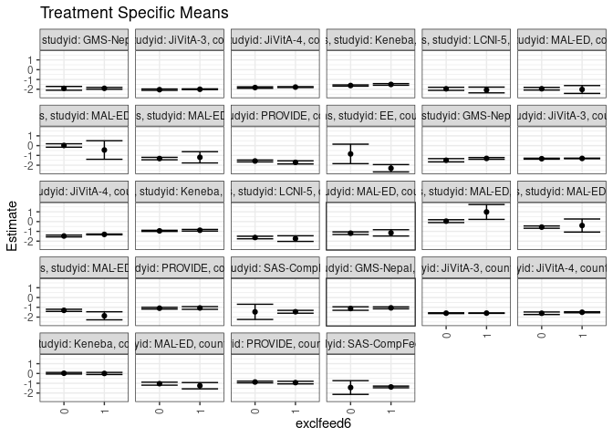

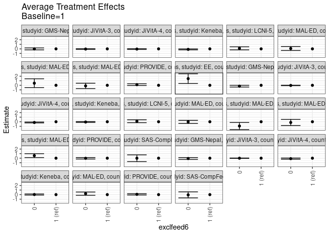

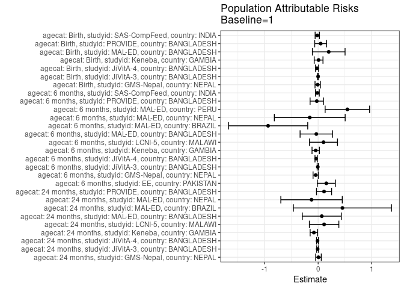

## Results Table

### Parameter: TSM

| agecat | studyid | country | intervention_level | baseline_level | estimate | ci_lower | ci_upper |
| --- | --- | --- | --- | --- | --- | --- | --- |
| Birth | GMS-Nepal | NEPAL | 1 | NA | -1.0555867 | -1.1531485 | -0.9580250 |
| Birth | GMS-Nepal | NEPAL | 0 | NA | -1.1257254 | -1.3027277 | -0.9487230 |
| Birth | JiVitA-3 | BANGLADESH | 1 | NA | -1.5945053 | -1.6192834 | -1.5697272 |
| Birth | JiVitA-3 | BANGLADESH | 0 | NA | -1.5991197 | -1.6384064 | -1.5598331 |
| Birth | JiVitA-4 | BANGLADESH | 1 | NA | -1.5064176 | -1.5583868 | -1.4544484 |
| Birth | JiVitA-4 | BANGLADESH | 0 | NA | -1.6063432 | -1.7350222 | -1.4776642 |
| Birth | Keneba | GAMBIA | 1 | NA | 0.0046013 | -0.1034707 | 0.1126732 |
| Birth | Keneba | GAMBIA | 0 | NA | 0.0248022 | -0.0544037 | 0.1040081 |
| Birth | MAL-ED | BANGLADESH | 1 | NA | -1.2503835 | -1.5716067 | -0.9291603 |
| Birth | MAL-ED | BANGLADESH | 0 | NA | -1.0419031 | -1.1952176 | -0.8885887 |
| Birth | PROVIDE | BANGLADESH | 1 | NA | -0.9322909 | -1.0660704 | -0.7985114 |
| Birth | PROVIDE | BANGLADESH | 0 | NA | -0.8712507 | -0.9595748 | -0.7829267 |
| Birth | SAS-CompFeed | INDIA | 1 | NA | -1.3776197 | -1.4631704 | -1.2920690 |
| Birth | SAS-CompFeed | INDIA | 0 | NA | -1.4364436 | -2.1366347 | -0.7362525 |
| 6 months | EE | PAKISTAN | 1 | NA | -2.3121318 | -2.6865239 | -1.9377397 |
| 6 months | EE | PAKISTAN | 0 | NA | -0.8473333 | -1.8424880 | 0.1478213 |
| 6 months | GMS-Nepal | NEPAL | 1 | NA | -1.3075262 | -1.3963026 | -1.2187498 |
| 6 months | GMS-Nepal | NEPAL | 0 | NA | -1.4945296 | -1.6616197 | -1.3274395 |
| 6 months | JiVitA-3 | BANGLADESH | 1 | NA | -1.3073749 | -1.3377457 | -1.2770041 |
| 6 months | JiVitA-3 | BANGLADESH | 0 | NA | -1.3367131 | -1.3859428 | -1.2874834 |
| 6 months | JiVitA-4 | BANGLADESH | 1 | NA | -1.3105840 | -1.3517241 | -1.2694438 |
| 6 months | JiVitA-4 | BANGLADESH | 0 | NA | -1.4737451 | -1.5661961 | -1.3812940 |
| 6 months | Keneba | GAMBIA | 1 | NA | -0.8870916 | -0.9720135 | -0.8021696 |
| 6 months | Keneba | GAMBIA | 0 | NA | -0.9496593 | -1.0072485 | -0.8920701 |
| 6 months | LCNI-5 | MALAWI | 1 | NA | -1.7394631 | -2.0281912 | -1.4507350 |
| 6 months | LCNI-5 | MALAWI | 0 | NA | -1.6273195 | -1.7585284 | -1.4961106 |
| 6 months | MAL-ED | BANGLADESH | 1 | NA | -1.1558128 | -1.4760066 | -0.8356191 |
| 6 months | MAL-ED | BANGLADESH | 0 | NA | -1.1872203 | -1.3190050 | -1.0554356 |
| 6 months | MAL-ED | BRAZIL | 1 | NA | 0.9830189 | 0.2231219 | 1.7429158 |
| 6 months | MAL-ED | BRAZIL | 0 | NA | 0.0437514 | -0.1014280 | 0.1889308 |
| 6 months | MAL-ED | NEPAL | 1 | NA | -0.4050000 | -1.0737079 | 0.2637079 |
| 6 months | MAL-ED | NEPAL | 0 | NA | -0.5658106 | -0.6826403 | -0.4489809 |
| 6 months | MAL-ED | PERU | 1 | NA | -1.8680000 | -2.2794681 | -1.4565319 |
| 6 months | MAL-ED | PERU | 0 | NA | -1.3117701 | -1.4224656 | -1.2010745 |
| 6 months | PROVIDE | BANGLADESH | 1 | NA | -1.0661240 | -1.2023175 | -0.9299304 |
| 6 months | PROVIDE | BANGLADESH | 0 | NA | -1.0908710 | -1.1788392 | -1.0029028 |
| 6 months | SAS-CompFeed | INDIA | 1 | NA | -1.4549959 | -1.6008850 | -1.3091069 |
| 6 months | SAS-CompFeed | INDIA | 0 | NA | -1.4654856 | -2.2428805 | -0.6880907 |
| 24 months | GMS-Nepal | NEPAL | 1 | NA | -1.9060050 | -2.0014792 | -1.8105307 |
| 24 months | GMS-Nepal | NEPAL | 0 | NA | -1.9088574 | -2.1040837 | -1.7136311 |
| 24 months | JiVitA-3 | BANGLADESH | 1 | NA | -2.0021704 | -2.0421101 | -1.9622307 |
| 24 months | JiVitA-3 | BANGLADESH | 0 | NA | -2.0444503 | -2.1141824 | -1.9747181 |
| 24 months | JiVitA-4 | BANGLADESH | 1 | NA | -1.7799757 | -1.8216887 | -1.7382627 |
| 24 months | JiVitA-4 | BANGLADESH | 0 | NA | -1.8258663 | -1.9003431 | -1.7513895 |
| 24 months | Keneba | GAMBIA | 1 | NA | -1.5080721 | -1.5924931 | -1.4236511 |
| 24 months | Keneba | GAMBIA | 0 | NA | -1.6200003 | -1.6858331 | -1.5541675 |
| 24 months | LCNI-5 | MALAWI | 1 | NA | -2.0762325 | -2.3714369 | -1.7810282 |
| 24 months | LCNI-5 | MALAWI | 0 | NA | -1.9555988 | -2.1145008 | -1.7966969 |
| 24 months | MAL-ED | BANGLADESH | 1 | NA | -2.0252564 | -2.4282478 | -1.6222650 |
| 24 months | MAL-ED | BANGLADESH | 0 | NA | -1.9481985 | -2.0823908 | -1.8140062 |
| 24 months | MAL-ED | BRAZIL | 1 | NA | -0.4472026 | -1.3959861 | 0.5015809 |
| 24 months | MAL-ED | BRAZIL | 0 | NA | 0.0146752 | -0.1578518 | 0.1872023 |
| 24 months | MAL-ED | NEPAL | 1 | NA | -1.1950000 | -1.7707330 | -0.6192670 |
| 24 months | MAL-ED | NEPAL | 0 | NA | -1.3216589 | -1.4457846 | -1.1975331 |
| 24 months | PROVIDE | BANGLADESH | 1 | NA | -1.7125860 | -1.8719878 | -1.5531843 |
| 24 months | PROVIDE | BANGLADESH | 0 | NA | -1.5697886 | -1.6659863 | -1.4735909 |

### Parameter: E(Y)

| agecat | studyid | country | intervention_level | baseline_level | estimate | ci_lower | ci_upper |
| --- | --- | --- | --- | --- | --- | --- | --- |
| Birth | GMS-Nepal | NEPAL | NA | NA | -1.0641208 | -1.1525364 | -0.9757052 |
| Birth | JiVitA-3 | BANGLADESH | NA | NA | -1.5955338 | -1.6186322 | -1.5724354 |
| Birth | JiVitA-4 | BANGLADESH | NA | NA | -1.5273138 | -1.5765339 | -1.4780937 |
| Birth | Keneba | GAMBIA | NA | NA | 0.0126443 | -0.0554367 | 0.0807254 |
| Birth | MAL-ED | BANGLADESH | NA | NA | -1.0530244 | -1.1913751 | -0.9146736 |
| Birth | PROVIDE | BANGLADESH | NA | NA | -0.8851020 | -0.9601332 | -0.8100709 |
| Birth | SAS-CompFeed | INDIA | NA | NA | -1.3937088 | -1.5095039 | -1.2779137 |
| 6 months | EE | PAKISTAN | NA | NA | -2.1595486 | -2.5331781 | -1.7859192 |
| 6 months | GMS-Nepal | NEPAL | NA | NA | -1.3540280 | -1.4334801 | -1.2745760 |
| 6 months | JiVitA-3 | BANGLADESH | NA | NA | -1.3138259 | -1.3418712 | -1.2857806 |
| 6 months | JiVitA-4 | BANGLADESH | NA | NA | -1.3482303 | -1.3866421 | -1.3098185 |
| 6 months | Keneba | GAMBIA | NA | NA | -0.9331108 | -0.9823173 | -0.8839043 |
| 6 months | LCNI-5 | MALAWI | NA | NA | -1.6395956 | -1.7592633 | -1.5199278 |
| 6 months | MAL-ED | BANGLADESH | NA | NA | -1.1900794 | -1.3096296 | -1.0705291 |
| 6 months | MAL-ED | BRAZIL | NA | NA | 0.0475758 | -0.0963508 | 0.1915023 |
| 6 months | MAL-ED | NEPAL | NA | NA | -0.5622370 | -0.6774081 | -0.4470660 |
| 6 months | MAL-ED | PERU | NA | NA | -1.3220326 | -1.4308168 | -1.2132484 |
| 6 months | PROVIDE | BANGLADESH | NA | NA | -1.0916915 | -1.1661176 | -1.0172654 |
| 6 months | SAS-CompFeed | INDIA | NA | NA | -1.4697236 | -1.6333919 | -1.3060553 |
| 24 months | GMS-Nepal | NEPAL | NA | NA | -1.9002128 | -1.9869255 | -1.8135001 |
| 24 months | JiVitA-3 | BANGLADESH | NA | NA | -2.0118003 | -2.0479952 | -1.9756055 |
| 24 months | JiVitA-4 | BANGLADESH | NA | NA | -1.7914765 | -1.8297816 | -1.7531715 |
| 24 months | Keneba | GAMBIA | NA | NA | -1.5876293 | -1.6406755 | -1.5345831 |
| 24 months | LCNI-5 | MALAWI | NA | NA | -1.9651323 | -2.1053230 | -1.8249415 |
| 24 months | MAL-ED | BANGLADESH | NA | NA | -1.9576341 | -2.0857597 | -1.8295086 |
| 24 months | MAL-ED | BRAZIL | NA | NA | 0.0061144 | -0.1625850 | 0.1748138 |
| 24 months | MAL-ED | NEPAL | NA | NA | -1.3187671 | -1.4406685 | -1.1968657 |
| 24 months | PROVIDE | BANGLADESH | NA | NA | -1.6024221 | -1.6857420 | -1.5191023 |

### Parameter: ATE

| agecat | studyid | country | intervention_level | baseline_level | estimate | ci_lower | ci_upper |
| --- | --- | --- | --- | --- | --- | --- | --- |
| Birth | GMS-Nepal | NEPAL | 1 | 1 | 0.0000000 | 0.0000000 | 0.0000000 |
| Birth | GMS-Nepal | NEPAL | 0 | 1 | -0.0701386 | -0.2652663 | 0.1249891 |
| Birth | JiVitA-3 | BANGLADESH | 1 | 1 | 0.0000000 | 0.0000000 | 0.0000000 |
| Birth | JiVitA-3 | BANGLADESH | 0 | 1 | -0.0046144 | -0.0453113 | 0.0360825 |
| Birth | JiVitA-4 | BANGLADESH | 1 | 1 | 0.0000000 | 0.0000000 | 0.0000000 |
| Birth | JiVitA-4 | BANGLADESH | 0 | 1 | -0.0999256 | -0.2379876 | 0.0381364 |
| Birth | Keneba | GAMBIA | 1 | 1 | 0.0000000 | 0.0000000 | 0.0000000 |
| Birth | Keneba | GAMBIA | 0 | 1 | 0.0202009 | -0.1046183 | 0.1450202 |
| Birth | MAL-ED | BANGLADESH | 1 | 1 | 0.0000000 | 0.0000000 | 0.0000000 |
| Birth | MAL-ED | BANGLADESH | 0 | 1 | 0.2084803 | -0.1489863 | 0.5659470 |
| Birth | PROVIDE | BANGLADESH | 1 | 1 | 0.0000000 | 0.0000000 | 0.0000000 |
| Birth | PROVIDE | BANGLADESH | 0 | 1 | 0.0610402 | -0.0868359 | 0.2089162 |
| Birth | SAS-CompFeed | INDIA | 1 | 1 | 0.0000000 | 0.0000000 | 0.0000000 |
| Birth | SAS-CompFeed | INDIA | 0 | 1 | -0.0588239 | -0.7253365 | 0.6076887 |
| 6 months | EE | PAKISTAN | 1 | 1 | 0.0000000 | 0.0000000 | 0.0000000 |
| 6 months | EE | PAKISTAN | 0 | 1 | 1.4647984 | 0.4015477 | 2.5280492 |
| 6 months | GMS-Nepal | NEPAL | 1 | 1 | 0.0000000 | 0.0000000 | 0.0000000 |
| 6 months | GMS-Nepal | NEPAL | 0 | 1 | -0.1870033 | -0.3752083 | 0.0012016 |
| 6 months | JiVitA-3 | BANGLADESH | 1 | 1 | 0.0000000 | 0.0000000 | 0.0000000 |
| 6 months | JiVitA-3 | BANGLADESH | 0 | 1 | -0.0293382 | -0.0814883 | 0.0228119 |
| 6 months | JiVitA-4 | BANGLADESH | 1 | 1 | 0.0000000 | 0.0000000 | 0.0000000 |
| 6 months | JiVitA-4 | BANGLADESH | 0 | 1 | -0.1631611 | -0.2628469 | -0.0634752 |
| 6 months | Keneba | GAMBIA | 1 | 1 | 0.0000000 | 0.0000000 | 0.0000000 |
| 6 months | Keneba | GAMBIA | 0 | 1 | -0.0625677 | -0.1611728 | 0.0360374 |
| 6 months | LCNI-5 | MALAWI | 1 | 1 | 0.0000000 | 0.0000000 | 0.0000000 |
| 6 months | LCNI-5 | MALAWI | 0 | 1 | 0.1121436 | -0.2038463 | 0.4281335 |
| 6 months | MAL-ED | BANGLADESH | 1 | 1 | 0.0000000 | 0.0000000 | 0.0000000 |
| 6 months | MAL-ED | BANGLADESH | 0 | 1 | -0.0314075 | -0.3777480 | 0.3149331 |
| 6 months | MAL-ED | BRAZIL | 1 | 1 | 0.0000000 | 0.0000000 | 0.0000000 |
| 6 months | MAL-ED | BRAZIL | 0 | 1 | -0.9392674 | -1.7170321 | -0.1615028 |
| 6 months | MAL-ED | NEPAL | 1 | 1 | 0.0000000 | 0.0000000 | 0.0000000 |
| 6 months | MAL-ED | NEPAL | 0 | 1 | -0.1608106 | -0.8396474 | 0.5180262 |
| 6 months | MAL-ED | PERU | 1 | 1 | 0.0000000 | 0.0000000 | 0.0000000 |
| 6 months | MAL-ED | PERU | 0 | 1 | 0.5562299 | 0.1301320 | 0.9823279 |
| 6 months | PROVIDE | BANGLADESH | 1 | 1 | 0.0000000 | 0.0000000 | 0.0000000 |
| 6 months | PROVIDE | BANGLADESH | 0 | 1 | -0.0247470 | -0.1872751 | 0.1377811 |
| 6 months | SAS-CompFeed | INDIA | 1 | 1 | 0.0000000 | 0.0000000 | 0.0000000 |
| 6 months | SAS-CompFeed | INDIA | 0 | 1 | -0.0104897 | -0.7471588 | 0.7261794 |
| 24 months | GMS-Nepal | NEPAL | 1 | 1 | 0.0000000 | 0.0000000 | 0.0000000 |
| 24 months | GMS-Nepal | NEPAL | 0 | 1 | -0.0028525 | -0.2194141 | 0.2137092 |
| 24 months | JiVitA-3 | BANGLADESH | 1 | 1 | 0.0000000 | 0.0000000 | 0.0000000 |
| 24 months | JiVitA-3 | BANGLADESH | 0 | 1 | -0.0422798 | -0.1189203 | 0.0343606 |
| 24 months | JiVitA-4 | BANGLADESH | 1 | 1 | 0.0000000 | 0.0000000 | 0.0000000 |
| 24 months | JiVitA-4 | BANGLADESH | 0 | 1 | -0.0458907 | -0.1261015 | 0.0343201 |
| 24 months | Keneba | GAMBIA | 1 | 1 | 0.0000000 | 0.0000000 | 0.0000000 |
| 24 months | Keneba | GAMBIA | 0 | 1 | -0.1119281 | -0.2171860 | -0.0066703 |
| 24 months | LCNI-5 | MALAWI | 1 | 1 | 0.0000000 | 0.0000000 | 0.0000000 |
| 24 months | LCNI-5 | MALAWI | 0 | 1 | 0.1206337 | -0.2150960 | 0.4563634 |
| 24 months | MAL-ED | BANGLADESH | 1 | 1 | 0.0000000 | 0.0000000 | 0.0000000 |
| 24 months | MAL-ED | BANGLADESH | 0 | 1 | 0.0770580 | -0.3478150 | 0.5019309 |
| 24 months | MAL-ED | BRAZIL | 1 | 1 | 0.0000000 | 0.0000000 | 0.0000000 |
| 24 months | MAL-ED | BRAZIL | 0 | 1 | 0.4618779 | -0.5042419 | 1.4279976 |
| 24 months | MAL-ED | NEPAL | 1 | 1 | 0.0000000 | 0.0000000 | 0.0000000 |
| 24 months | MAL-ED | NEPAL | 0 | 1 | -0.1266589 | -0.7156204 | 0.4623026 |
| 24 months | PROVIDE | BANGLADESH | 1 | 1 | 0.0000000 | 0.0000000 | 0.0000000 |
| 24 months | PROVIDE | BANGLADESH | 0 | 1 | 0.1427975 | -0.0415391 | 0.3271340 |

### Parameter: PAR

| agecat | studyid | country | intervention_level | baseline_level | estimate | ci_lower | ci_upper |
| --- | --- | --- | --- | --- | --- | --- | --- |
| Birth | GMS-Nepal | NEPAL | 1 | NA | -0.0085340 | -0.0585979 | 0.0415298 |
| Birth | JiVitA-3 | BANGLADESH | 1 | NA | -0.0010284 | -0.0100412 | 0.0079843 |
| Birth | JiVitA-4 | BANGLADESH | 1 | NA | -0.0208963 | -0.0494649 | 0.0076724 |
| Birth | Keneba | GAMBIA | 1 | NA | 0.0080431 | -0.0738970 | 0.0899831 |
| Birth | MAL-ED | BANGLADESH | 1 | NA | 0.1973591 | -0.1081437 | 0.5028618 |
| Birth | PROVIDE | BANGLADESH | 1 | NA | 0.0471888 | -0.0641831 | 0.1585608 |
| Birth | SAS-CompFeed | INDIA | 1 | NA | -0.0160891 | -0.0566754 | 0.0244973 |
| 6 months | EE | PAKISTAN | 1 | NA | 0.1525832 | -0.0166253 | 0.3217917 |
| 6 months | GMS-Nepal | NEPAL | 1 | NA | -0.0465018 | -0.0954299 | 0.0024263 |
| 6 months | JiVitA-3 | BANGLADESH | 1 | NA | -0.0064510 | -0.0184067 | 0.0055047 |
| 6 months | JiVitA-4 | BANGLADESH | 1 | NA | -0.0376464 | -0.0593042 | -0.0159885 |
| 6 months | Keneba | GAMBIA | 1 | NA | -0.0460192 | -0.1148104 | 0.0227720 |
| 6 months | LCNI-5 | MALAWI | 1 | NA | 0.0998675 | -0.1621352 | 0.3618702 |
| 6 months | MAL-ED | BANGLADESH | 1 | NA | -0.0342666 | -0.3379005 | 0.2693674 |
| 6 months | MAL-ED | BRAZIL | 1 | NA | -0.9354431 | -1.6758020 | -0.1950842 |
| 6 months | MAL-ED | NEPAL | 1 | NA | -0.1572370 | -0.8191102 | 0.5046361 |
| 6 months | MAL-ED | PERU | 1 | NA | 0.5459674 | 0.1304259 | 0.9615089 |
| 6 months | PROVIDE | BANGLADESH | 1 | NA | -0.0255675 | -0.1506626 | 0.0995275 |
| 6 months | SAS-CompFeed | INDIA | 1 | NA | -0.0147277 | -0.0507565 | 0.0213012 |
| 24 months | GMS-Nepal | NEPAL | 1 | NA | 0.0057922 | -0.0463745 | 0.0579589 |
| 24 months | JiVitA-3 | BANGLADESH | 1 | NA | -0.0096299 | -0.0271931 | 0.0079333 |
| 24 months | JiVitA-4 | BANGLADESH | 1 | NA | -0.0115009 | -0.0289926 | 0.0059909 |
| 24 months | Keneba | GAMBIA | 1 | NA | -0.0795572 | -0.1497848 | -0.0093296 |
| 24 months | LCNI-5 | MALAWI | 1 | NA | 0.1111003 | -0.1645947 | 0.3867953 |
| 24 months | MAL-ED | BANGLADESH | 1 | NA | 0.0676223 | -0.2968741 | 0.4321187 |
| 24 months | MAL-ED | BRAZIL | 1 | NA | 0.4533170 | -0.4634608 | 1.3700949 |
| 24 months | MAL-ED | NEPAL | 1 | NA | -0.1237671 | -0.6980101 | 0.4504758 |
| 24 months | PROVIDE | BANGLADESH | 1 | NA | 0.1101639 | -0.0308160 | 0.2511438 |